# The Politics of Corruption

Lecture 1: Welcome, and What Is Corruption?

Bogdan G. Popescu

bgpopescu@tec.mx

Tecnológico de Monterrey

# The Course

## What you will be able to do

- Distinguish bribery, fraud, clientelism, patronage, state capture
- Explain why corruption persists in some countries
- Weigh what the evidence says corruption costs
- Compare how some countries reduced corruption, and why
- Read a study and say what it actually established

## The path

- **Sessions 1–6** — concepts, evidence, and the U.S. case
- **Midterm review** S7 · **Midterm** — **Thu, Sep 24** (Sessions 1–6)
- **Sessions 8–13** — measurement, clientelism, China, kleptocracy, crime, technology
- **Final review** S14–S15 · **Final** — **Thu, Dec 3** (Sessions 8–14)
- No class: Semana Tec **Sep 14–18** and **Oct 26–30**; Revolution Day **Mon, Nov 16**

## Logistics

- **Meetings**: **Monday** lecture · **Thursday** discussion and presentations
- **Term**: Aug 10 – Dec 4, 2026 · no class Semana Tec (Sep 14–18, Oct 26–30) or Revolution Day (Mon, Nov 16)
- **Office Hours**: by appointment — bgpopescu@tec.mx
- **Materials**: course site, one page per session — slides and readings (PDF)
- **Readings**: **Required** = done before class, examinable · **Recommended** = depth. Both are used for presentations
- **Exams**: midterm **Thu, Sep 24** · final **Thu, Dec 3** — in class, closed book

## Grading and rules

| Component | Weight |
| --- | --- |
| Contributions | **33%** |
| Midterm exam | **33%** |
| Final exam | **33%** |

**Contributions** — the average of:

- **Presentation** — one 10-minute talk on an assigned reading
- **Presence** — attendance across the term
- **Participation** — what you contribute to discussion
- **Questions** — two per session, before 11pm Wednesday
- **Quality of questions** — judged on substance, not submission

## Questions Every Session

Submit **two questions** on the session’s readings before **11pm Wednesday**, ahead of the Thursday discussion. They guide it.

Each question should be between 50 and 100 words.

Begin by referencing a specific part of the text or its overarching claim. Then ask a critical question that opens discussion rather than testing recall.

Questions are graded on quality, not just submission.

## Example Question

**Note**

Nye argues that corruption can sometimes help a poor country develop, because bribes let people get around slow official rules and finally get things done. But if bribes are what make slow rules profitable, why would any official ever simplify them? Someone who earns from delay has a reason to create more delay. Nye treats red tape as a fixed obstacle that corruption helps people escape. What if corruption is what produces the red tape in the first place? How would we tell those two apart?

**Why is it good?**

- 50–100 words
- Points at one specific claim, not “the reading” in general
- Asks a question instead of summarizing
- Offers a rival explanation — corruption may cause the red tape, not cure it

## Presentations

- **One per student**: an assigned **reading**, on a **Thursday** — starting **Aug 20**, two or three of you each week
- **Format**: 10 minutes
- **Structure**: clear introduction, main points, conclusion
- **Critical analysis**: go beyond summary — what the author does not address, the limits of the evidence, rival explanations
- **Close on a verdict**: well supported · plausible but not established · not established by these data
- **Visual aids**: legible text, relevant visuals, no overloaded slides
- **Preparation**: practice for time; do not read verbatim from slides or notes
- **Engage**: be ready for 2–3 questions from peers or the instructor

## How presentations are graded

| Criterion | Points |
| --- | --- |
| **Critical analysis and verdict** — the unstated premise, rival explanations, a defensible verdict | 30 |
| **Content knowledge** — the claim that matters, and the evidence behind it | 20 |
| **Selection and focus** — one line of argument, developed, within the time | 15 |
| **Organization** — introduction, main points, conclusion | 15 |
| **Clarity of expression** | 10 |
| **Engagement and response** — speaking to the room, handling questions | 10 |

Analysis outweighs coverage. At ten minutes, **choosing well is the skill**.

# Part I: The Puzzle — Four Cases

## Today’s game: “Is this corruption?”

Four real situations — three from Latin America, one from the United States.

For each one, you will vote:

- **Clearly corrupt**
- **Not corrupt**
- **It’s complicated**

Write your four votes down — we will return to them at the end.

## Case 1 — A police stop on the street

Mexico

- A driver runs a red light in the city
- The official fine: money, points, a lost morning
- The officer hints: *“Podemos arreglarlo aquí”*
- Two hundred pesos change hands; no ticket, no record
- Both sides walk away better off — today

Corrupt? Who exactly is the victim?

[figure not shown]

Transit officer stopping a car, Mexico City

Photo: ProtoplasmaKid, Wikimedia Commons, CC BY-SA 4.0.

## Case 2 — Despensas before the vote

Mexico

- Election week, a low-income neighborhood
- Party workers hand out grocery packages and store gift cards
- Names are noted; benefits, it is hinted, depend on winning
- 2012: the “Soriana card” *accusations* — never proven in court
- Nobody was coerced; campaigns give things away everywhere

Corrupt? A gift, a wage, or a purchase?

## Case 3 — The revolving door

United States

- A senior financial regulator supervises a major bank for years
- Soon after they leave office, that bank hires them — at triple pay
- Entirely legal after a short cooling-off period
- Expertise should be employable; who else knows the rules so well?
- But: did the *prospect* of the job soften supervision earlier?

Corrupt? Nothing was ever exchanged — perhaps.

## Case 4 — La Estafa Maestra

Mexico

- 2013–2014: eleven Mexican government agencies awarded contracts to eight public universities
- The universities were supposed to carry out public projects
  - instead they subcontracted most of the work to private companies
  - Of the 186 companies hired, 128 were shell companies or irregular firms, or could not be located
- Journalists traced 7,670 million pesos of diverted public money

Corrupt? Here, almost nobody hesitates. Why?

Source: Animal Político & Mexicanos Contra la Corrupción y la Impunidad (2017).

## Exercise 1 — Vote and defend

≈ 5 minutes

**Prompt.** In pairs: rank the four cases from *most clearly corrupt* to *least clearly corrupt*.

1. Compare your votes on the four cases.
2. Why is it corrupt, or why not?

Keep your test visible — we are about to stress-test it.

## The four cases, side by side

|  | Case | Where | In one line |
| --- | --- | --- | --- |
| **1** | A police stop on the street | Mexico | red light · 200 pesos · no ticket, no record |
| **2** | Despensas before the vote | Mexico | election week · groceries and gift cards · names noted |
| **3** | The revolving door | United States | regulator supervises a bank · the bank then hires them |
| **4** | La Estafa Maestra | Mexico | contracts via public universities · shell companies · 7,670 million pesos |

Rank these. Keep your test in one sentence.

## What did our disagreement reveal?

Call out your pair’s test — let’s collect them.

Tests that usually surface, and where they clash:

- **Legality** — some cases were illegal but small, others legal but vast
- **Harm** — diffuse in some cases, brutal in others
- **Motive** — some actors believed they were doing their jobs

**So what?** Intuition alone cannot draw the line. There is no neutral way to count corruption — before we can measure it, prosecute it, or reform it, we have to decide what counts.

# Part II: Defining Corruption

## How three institutions approach corruption

| Institution | How it frames corruption | Where it draws the line |
| --- | --- | --- |
| World Bank (1997) | “the abuse of public office for private gain” | the public sector |
| Transparency International | “the abuse of entrusted power for private gain” | public **and** private power |
| OECD (2008) | no single definition; specifies criminal acts — bribery of officials, trading in influence | prosecutable offences |

- All three come from *reform* institutions — built for measuring and prosecuting, not for settling what corruption *is*

Sources: World Bank (1997); Transparency International (2025); OECD (2008).

## Stress test — the revolving door

Back to **Case 3**: the regulator supervises a bank, then the bank hires them.

Did corruption occur?

- **World Bank** — only if they abused public office *while still in government*
- **Transparency International** — only if they abused the power entrusted to them
- **OECD** — taking the job is not, in itself, a bribery offence

Same facts. Not one definition gives a clean yes or no.

## Three questions to ask about any case

When you think something might be corrupt, ask:

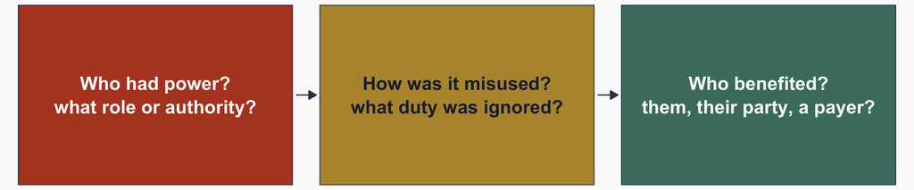

- **Case 1, the traffic stop:** police authority → the ticket is never written → 200 pesos to the officer
- The technical names for the same three: **entrusted power** → **deviation from duty** → **private gain**
- Most definitions wrestle with the same three problems — but disagree about what counts as power, misuse, and gain
- The hardest is the middle one: **what standard tells us power was *misused*?**

## Three ways to define corruption

Three scholarly answers to that middle question — **misused by what standard?**

| Approach | Conduct is corrupt when it violates… | Example |
| --- | --- | --- |
| **Public office** | the formal duties of a public official | Nye (1967) |
| **Public interest** | the broader interests of society | Friedrich |
| **Public opinion** | what citizens generally regard as corrupt | survey-based approaches |

But each standard creates a problem:

- **Public office:** what if the rules themselves are corrupt?
- **Public interest:** who decides what counts as the “public interest”?
- **Public opinion:** what if citizens disagree?

Classification following Heidenheimer (1970).

## Nye’s public-office definition

**Nye (1967):** corruption is a **deviation from the formal duties of a public role** for **private gain**.

- **Strength:** gives us a clear benchmark — **what are the official duties and rules?**
- **Limitation:** it makes **formal rules** the standard for deciding what counts as corruption

### But what if the rules themselves permit favoritism?

**Legal ≠ necessarily honest**

Lobbying, patronage, preferential access, or conflicts of interest may influence public decisions **without violating formal duties**.

## Change the measure, change the picture

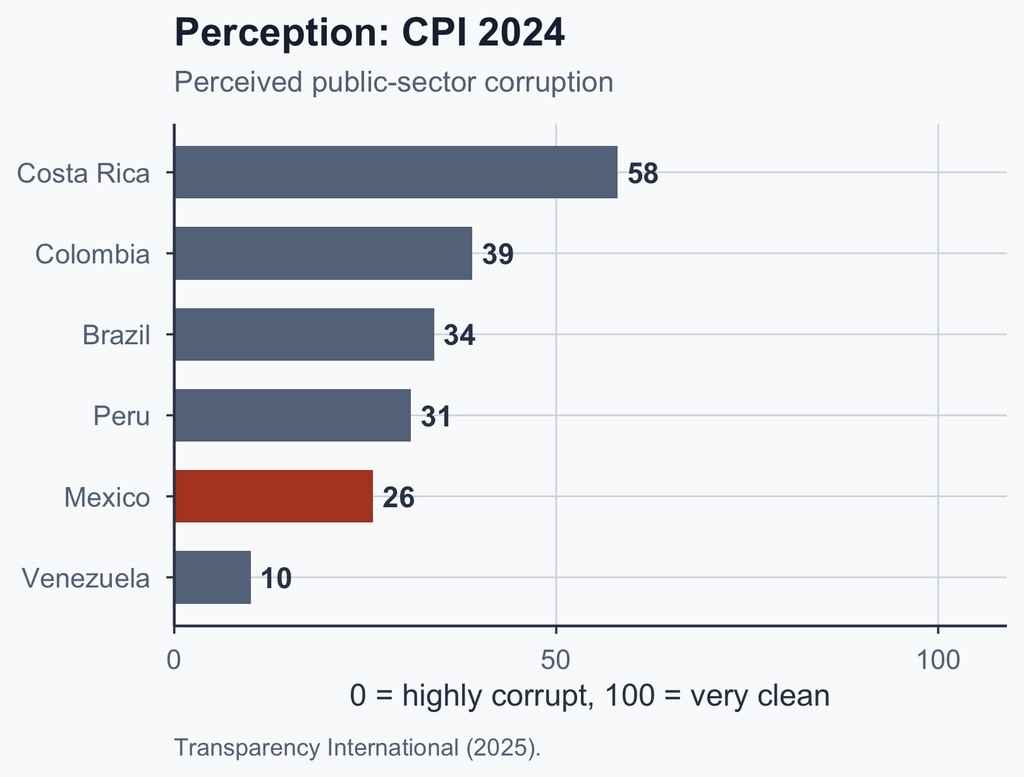

[figure not shown]

**So what?** 26/100 on perception, 34% on experience — these do not contradict each other; they measure different things. “Corruption” is an umbrella: next we name the parts.

# Part III: A Vocabulary of Corrupt Acts

## Mapping the terrain: what does the actor do?

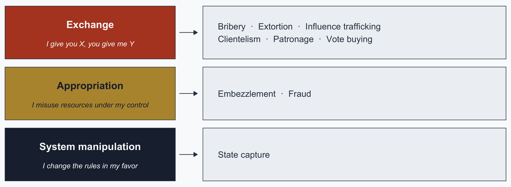

- These are **mechanisms, not mutually exclusive boxes** — one scandal can involve several at once

Author’s illustration. The individual terms are standard in the literature; the grouping by mechanism is the author’s.

## What is being exchanged?

**Money or favors → decisions**

- **Bribery**: giving a benefit to influence an official decision
- **Extortion**: demanding a payment through threats or coercion
- **Influence trafficking**: selling access or influence over a decision-maker

**Benefits → political support**

- **Clientelism**: repeated benefits in exchange for political support
- **Patronage**: public jobs in exchange for political loyalty
- **Vote buying**: money or goods in exchange for a vote

**The key question: what is the exchange?**

- Lobbying: trying to influence a decision through permitted advocacy
- Influence trafficking: selling improper access or influence
- Case 1 — mordida: Was the payment offered, demanded, or forced?
- Case 2 — despensas: Were the goods given in exchange for votes?

## Appropriation: embezzlement and fraud

- **Embezzlement**: diverting resources you were entrusted to manage
- **Fraud**: deception — phantom firms, fake invoices, ghost workers
- Often no victim on the spot, so no complaints — detection needs **audits**
- But fraud can be collusive too: fake bidders are an *exchange*
- La Estafa Maestra combined diversion, deception, and collusion

[figure not shown]

“Who stole the people’s money?” — everyone points elsewhere

Thomas Nast, Harper’s Weekly, 1871. Wikimedia Commons, public domain.

## System manipulation: state capture

- Firms or elites shape **the rules themselves**, not their application
- Laws, decrees, court doctrine — written to order (Hellman, Jones, & Kaufmann, 2003)
- Ordinary bribery bends existing rules; capture *rewrites* them
- Once capture succeeds, the conduct it protects becomes **legal**
- **A clean example:** a beverage association drafts the sugar-tax rules; congress adopts them verbatim

No bribe is needed. The rule itself is the payoff.

## The four cases, classified

Designated summary slide — our vocabulary applied:

| Case | Best label | Illegal? | Entrusted power abused? |
| --- | --- | --- | --- |
| 1. Police stop | petty bribery / extortion | yes | yes — police discretion |
| 2. Despensas | vote buying / clientelism | the practice: yes; the 2012 case: alleged | yes — via party machine |
| 3. Revolving door | influence trafficking | no | anticipated, not proven |
| 4. Estafa Maestra | embezzlement + fraud | yes | yes — budget authority |

- Alleged, documented, unethical, illegal, convicted — **different claims; keep them apart**
- One “no” entry in the *Illegal?* column — hold that thought

## Exercise 2 — Name that act

≈ 5 minutes

**Prompt.** Classify each scenario with one vocabulary term; be ready to defend your choice:

1. A mayor puts a campaign worker on the payroll as “special advisor”; he never appears at work.
2. A customs officer charges $20 to process *legal* imports faster.
3. A health official’s hidden firm wins the ambulance contract via fake bidders.
4. A construction group funds the campaign of the legislator writing the procurement law; the final text exempts contracts like theirs.

Scenarios overlap — but some labels fit the defining mechanism better than others.

## So what? — The legal cases remain

- One of our four cases was legal; no prosecutor could touch it
- How these acts *combine* varies from country to country — a theme we return to later in the course

**So what?** If corruption can be perfectly legal, illegality-based definitions miss it entirely. So what do we call the legal cases?

# Part IV: Legal Corruption

## What if corruption is legal?

Back to **Case 3** — the regulator who later joins the bank:

- **No bribe. No stolen money. No rule necessarily broken.**
- But the regulator knows the bank might hire them later
- So **today**, they may regulate the bank less aggressively
- **Later**, the reward comes as a normal salary

## Why is this a problem?

The system can distort public decisions **without anyone explicitly breaking the rules**.

**Thompson (2018): institutional corruption**

> **Corruption can exist even without a corrupt individual.**

The problem lies in the **incentives built into the institution**, not necessarily in a secret deal or guilty intent.

## Definitions decide what we see

There is no neutral way to count corruption.

Today’s single idea, three consequences:

- Definition → **measurement**: CPI counts perceptions; barometers count experiences
- Definition → **law**: OECD-style offences reach bribes, not revolving doors
- Definition → **reform**: punish individuals, or redesign institutions?
- Legal corruption is invisible to every illegality-based measure
- What your country counts shapes what it fixes

## Conclusion — six things to take away

1. **Corruption is contested by design** — four cases
2. **Definitions are choices** — public office, entrusted power, or specified offences
3. **Three questions travel anywhere** — who had power, how was it misused, who benefited
4. **The real fight is over “misused”** — formal duty, public interest, or public opinion
5. **Three families of act** — exchange, appropriation, system manipulation
6. **Some corruption is legal** — and invisible to every illegality-based measure

Look back at your four votes from the opening: which one changed, and *which definition* changed it?

## References

Animal Político & Mexicanos Contra la Corrupción y la Impunidad. (2017). *La Estafa Maestra: Graduados en desaparecer dinero público*. https://www.animalpolitico.com/estafa-maestra/

Heidenheimer, A. J. (Ed.). (1970). *Political corruption: Readings in comparative analysis*. Holt, Rinehart and Winston.

Hellman, J. S., Jones, G., & Kaufmann, D. (2003). Seize the state, seize the day: State capture and influence in transition economies. *Journal of Comparative Economics, 31*(4), 751–773. https://doi.org/10.1016/j.jce.2003.09.006

Nye, J. S. (1967). Corruption and political development: A cost-benefit analysis. *American Political Science Review, 61*(2), 417–427. https://doi.org/10.2307/1953254

OECD. (2008). *Corruption: A glossary of international standards in criminal law*. OECD Publishing.

## References (continued)

Thompson, D. F. (2018). Theories of institutional corruption. *Annual Review of Political Science, 21*, 495–513. https://doi.org/10.1146/annurev-polisci-120117-110316

Transparency International. (2019). *Global Corruption Barometer — Latin America & the Caribbean 2019: Citizens’ views and experiences of corruption*. Transparency International.

Transparency International. (2025). *Corruption Perceptions Index 2024*. Transparency International. https://www.transparency.org/en/cpi/2024

United Nations. (2003). *United Nations Convention against Corruption*. United Nations Office on Drugs and Crime.

World Bank. (1997). *Helping countries combat corruption: The role of the World Bank*. World Bank.